# Propriedades da Distribuição Normal Multivariada

Vicente G. Cancho

10/09/2022

## Distribuição Normal Multivariada

Dizemos que um vetor aleatório $\boldsymbol{X}$ de ordem ($p\times 1$) tem distribuição normal multivariada (ou $p$-variada) com vetor de médias $\boldsymbol{\mu}$ e matriz de variâncias e covariâncias $\Sigma$ de ordem $p\times p$, se sua função de densidade conjunta é dada por
$$f(\boldsymbol{x})=(2\pi
|\Sigma|)^{-1/2}\exp\left\{-\frac{1}{2}(\boldsymbol{x}-\boldsymbol{\mu})^\top\Sigma^{-1}(\boldsymbol{x}-\boldsymbol{\mu})\right\},\;
\boldsymbol{x}\in R^p,$$
onde $\boldsymbol{\mu}=\left[\begin{array}{c} \mu_1\\ \mu_2\\ \vdots\\ \mu_p \end{array} \right]$ e $\boldsymbol{\Sigma}=\left(\begin{array}{llll} \sigma_{11}& \sigma_{12}&\dots& \sigma_{1p} \\ \sigma_{21}& \sigma_{22}&\dots& \sigma_{2p} \\ \vdots& \vdots&\dots&\vdots\\ \sigma_{p1}& \sigma_{p2}&\dots& \sigma_{pp} \end{array}\right).$

Notação: $\boldsymbol{X}\sim N_p(\boldsymbol{\mu},\boldsymbol\Sigma).$

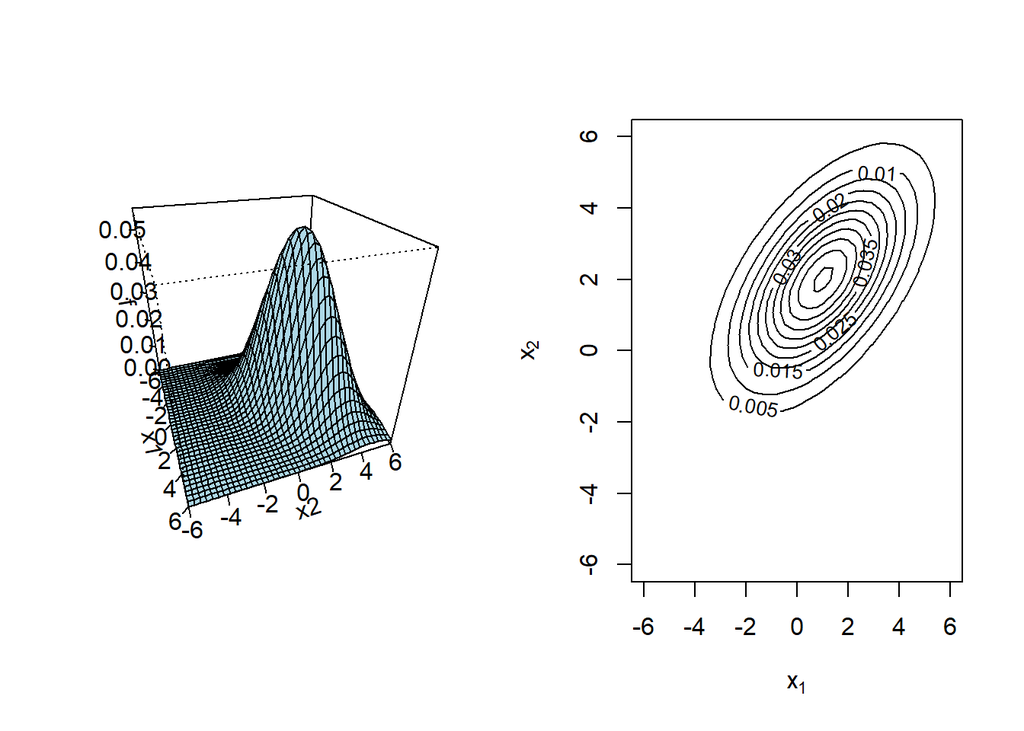

```r
library(grDevices)
library(mvtnorm)
# vetor de médias
mu = matrix(c(1,2), nrow=2)
# matriz de variâncias e covariâncias:
Sigma =matrix(c(4,2,2,3), ncol=2)
## Grafico da f.d.p e contornos
x1=seq(-6, 6, length= 40)
x2 = x1
f = matrix(0, nrow=length(x1), ncol=length(x2))
for (i in 1:length(x1)){
  for (j in 1: length(x2)){
    f[i,j]=dmvnorm(c(x1[i],x2[j]), mean=mu, sigma=Sigma)}}

par(mfrow=c(1,2))
persp(x1, x2, f, theta = 70, phi = 30, col = "lightblue", ticktype = "detailed")
contour(x1, x2, f, draw=T, nlevels=20, labcex=0.8,
        xlab=expression(x[1]),ylab=expression(x[2]))
```

### Amostras de uma distribuição Normal Multivariada

- Se $\boldsymbol{X}\sim N_p(\boldsymbol{\mu},\boldsymbol\Sigma)$ então
  $$\boldsymbol{Y}=\Sigma^{-1/2}(\boldsymbol{X}-\boldsymbol{\mu})\sim
  N(\boldsymbol{0},\boldsymbol{I}_p),$$
  onde $\Sigma^{-1/2}$ é a matriz raiz quadrada de $\Sigma^{-1}$.
- Se $\boldsymbol{Y}\sim N(\boldsymbol{0},\boldsymbol{I}_p)$ então
  $$\boldsymbol{X}=\Sigma^{1/2}\boldsymbol{Y}+\boldsymbol{\mu}\sim
  N(\boldsymbol{\boldsymbol{\mu}},\boldsymbol{\Sigma}),$$
  onde $\Sigma^{1/2}$ é a matriz raiz quadrada de $\Sigma$
- Decomposição espectral da matriz de variância-covariância:
  $$\Sigma=\boldsymbol{\Gamma}\boldsymbol{\Lambda}\boldsymbol{\Gamma}^\top$$
  onde $\boldsymbol{\Lambda}=diag(\lambda_1,\dots,\lambda_p)$, onde $\lambda_j$ é o j-ésimo autovalor de $\Sigma$, $\boldsymbol{\Gamma}=(\boldsymbol\gamma_1,\dots,\boldsymbol\gamma_p)_{p\times p}$ com $\boldsymbol\gamma_j$ é $j$-ésimo autovalor associado a $\lambda_j$ . Note que $\boldsymbol{\Gamma}$ é uma matriz ortogonal, ou seja $\boldsymbol\Gamma^\top\boldsymbol\Gamma=\boldsymbol\Gamma\boldsymbol\Gamma^\top=\boldsymbol{I}_n$
- A matriz raiz quadrada de $\Sigma$ é dada por
  $$\Sigma ^{1/2}
  = \boldsymbol{\Gamma} \Lambda ^{1/2} \boldsymbol{\Gamma} ^\top
  = \sum_{i=1}^{k}\sqrt
  {\lambda_i} \boldsymbol{\gamma}_i \boldsymbol{\gamma}_i^\top,$$

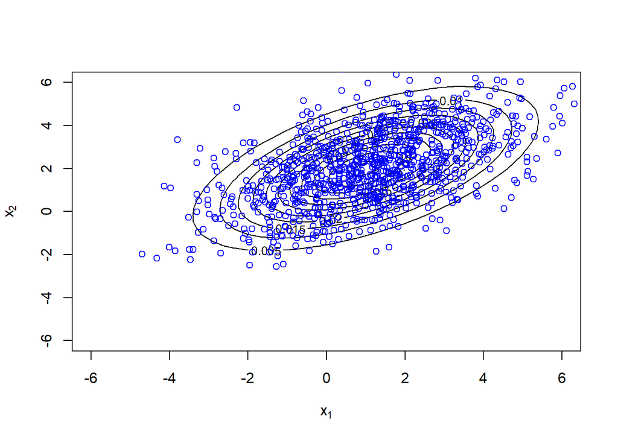

```r
##################################################################
## Gera amostras N_p(mu,Sigma) baseada na decomposição espectral #
##################################################################
anmv=function(n,mu,Sigma){
ES = eigen(Sigma)
lambda = ES$values
U = ES$vectors
Sigma_half=U %*% diag(sqrt(lambda)) %*% t(U)
p = length(mu)
Z = matrix(rnorm(n*p),ncol = n, nrow = p)
X =Sigma_half%*% Z + c(mu)
X
}
set.seed(123)
X=anmv(1000,mu,Sigma)
contour(x1, x2, f, draw=T, nlevels=20, labcex=0.8,
        xlab=expression(x[1]),ylab=expression(x[2]))
points(X[1,],X[2,],col="blue")
```

```r
apply(X,1,mean)
```

```
## [1] 1.085914 2.053989
```

```r
cov(t(X))
```

```
##          [,1]     [,2]
## [1,] 3.691924 1.755501
## [2,] 1.755501 2.992674
```

```r
########################################################
## Uso do pacote mnormt
#######################################################
library(mnormt)
X1=rmnorm(n = 1000,  mu, Sigma)
dim(X1)
```

```
## [1] 1000    2
```

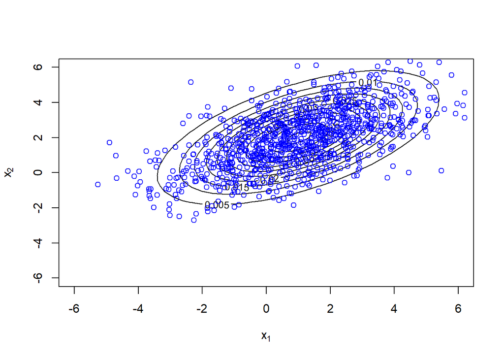

```r
contour(x1, x2, f, draw=T, nlevels=20, labcex=0.8,
        xlab=expression(x[1]),ylab=expression(x[2]))
points(X1[,1],X1[,2],col="blue")
```

```r
apply(X1,2,mean)
```

```
## [1] 0.9682836 1.9651705
```

```r
cov(X1)
```

```
##          [,1]     [,2]
## [1,] 3.998011 2.013709
## [2,] 2.013709 2.899205
```

## Teorema do Limite Central Multivariado

Se $\boldsymbol{X}_1,\boldsymbol{X}_2,\ldots$ é uma sequência vetores aleatórios i.i.d, de dimensão $p$ com $E[\boldsymbol{X}]=\boldsymbol{\mu}$ e $Cov(\boldsymbol{X})=\boldsymbol\Sigma$ (positiva definida) então
$$n^{-1/2}\sum_{j=1}^{n}\left(\boldsymbol{X}_j
-\boldsymbol{\mu}\right)\stackrel{d}{\longrightarrow}N_p(\boldsymbol{0},\boldsymbol\Sigma),\;
n\longrightarrow \infty.$$
ou
$$n^{1/2}\left(\bar{\boldsymbol{X}}_-
\boldsymbol{\mu}\right)\stackrel{d}{\longrightarrow}N_p(\boldsymbol{0},\boldsymbol\Sigma),\;
n\longrightarrow \infty.$$

### Exemplo-Distribuição multinomail

Dizemos que o vetor aleatório $\boldsymbol{X}=(X_1,\dots, X_k)$ têm distribuição multinomial com o vetor de parâmetros $r$e $\boldsymbol{\theta}=(\theta_1,\dots, \theta_k)$ se sua f.p é dado por
$$f(\boldsymbol{x};\boldsymbol{\theta})=\frac{r!}{x_1!\dots
x_k!}\theta_1^{x_1}\dots\theta_k^{x_k},\;\theta_j\in (0,1)$$
com $\theta_1+\dots+\theta_k=1$ e $x_1+\dots+x_k=r$.

Notação: $\boldsymbol{X}\sim \text{Multinomial}(r,\boldsymbol{\theta})$.

A vetor de média e matriz de covariância são dados $\boldsymbol{\mu}=\left[\begin{array}{c} r\theta_1\\ r\theta_2\\ \vdots\\ r\theta_k \end{array} \right]$ e $\boldsymbol{\Sigma}=\left(\begin{array}{llll} r\theta_{1}(1-\theta_{1})& -r\theta_1\theta_{2}&\dots& -r\theta_1\theta{k} \\ -r\theta_1\theta_{2}& r\theta_{2}(1-\theta_{2})&\dots& -r\theta_2\theta{k} \\ \vdots& \vdots&\dots&\vdots\\ -r\theta_1\theta_{k}& -r\theta_2\theta_{k}&\dots& r\theta_{k}(1-\theta_{k}) \end{array}\right).$

- Supor que $\boldsymbol{X}_1,\dots,\boldsymbol{X}_n$ é uma amostra aleatória de uma população com $\text{Multinomial}(r,\boldsymbol{\theta})$, pelo TCL $\overline{\boldsymbol{X}}$ tem distribuição assintótica com vetor de médias $\boldsymbol{\mu}$ e matriz variância-covariância $\Sigma/n$.

```r
M=NULL
iREP=1000
n=100
r=50
prob=c(0.1,0.3,0.6)
rep=0
while(rep<iREP){
  y=t(rmultinom(n, r, prob))
  my=apply(y,2,mean)
  M=rbind(M,my)
 rep=rep+1
}
head(M,10)
```

```
##    [,1]  [,2]  [,3]
## my 4.85 15.14 30.01
## my 4.85 14.74 30.41
## my 4.98 14.68 30.34
## my 5.00 15.20 29.80
## my 4.91 15.12 29.97
## my 5.13 14.54 30.33
## my 5.14 14.48 30.38
## my 4.83 15.82 29.35
## my 4.84 14.92 30.24
## my 4.89 15.51 29.60
```

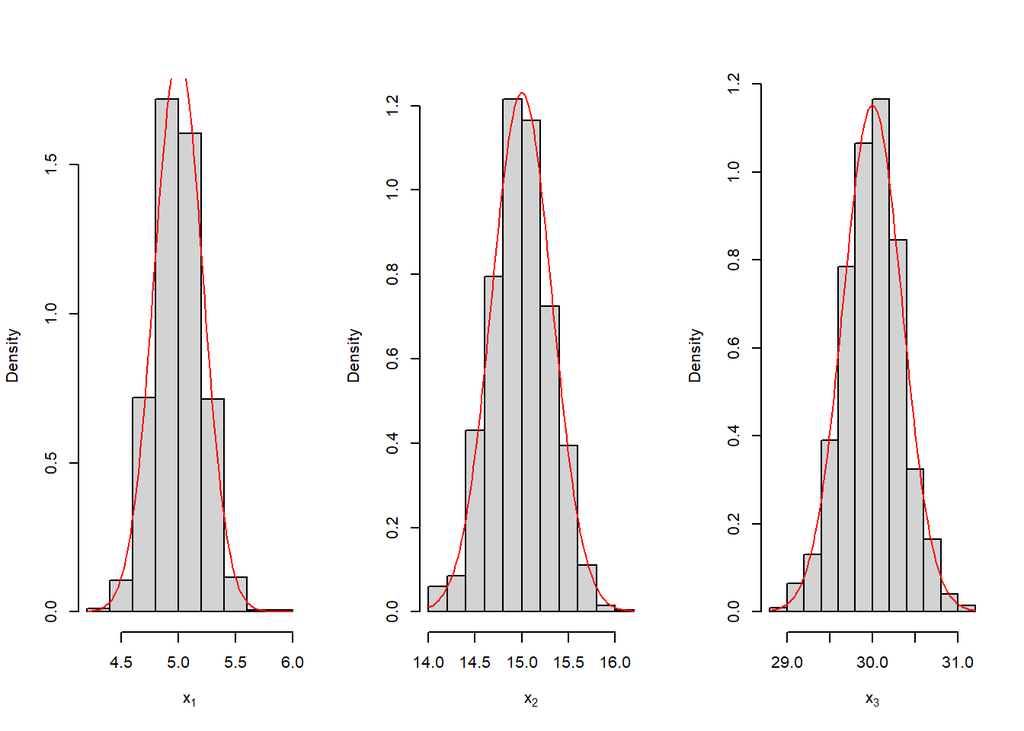

```r
par(mfrow=c(1,3))
hist(M[,1],prob=T,xlab=expression(x[1]),main="")
curve(dnorm(x, r*prob[1],sd=sqrt(r*prob[1]*(1-prob[1])/n)),add=T,col="red")
hist(M[,2],prob=T,xlab=expression(x[2]),main=" ")
curve(dnorm(x, r*prob[2],sd=sqrt(r*prob[2]*(1-prob[2])/n)),add=T,col="red")

hist(M[,3],prob=T,xlab=expression(x[3]), main="")
curve(dnorm(x, r*prob[3],sd=sqrt(r*prob[3]*(1-prob[3])/n)),add=T,col="red")
```

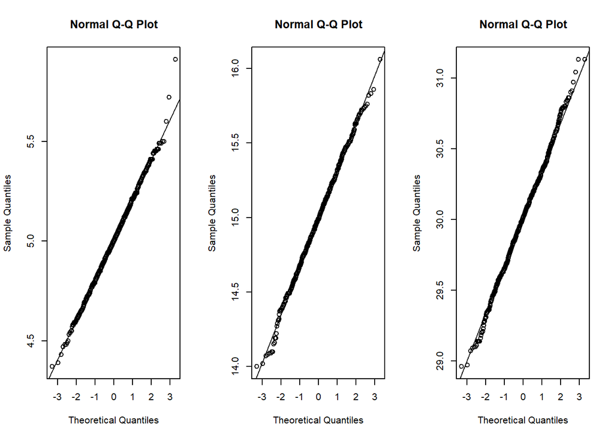

```r
par(mfrow=c(1,3))
qqnorm(M[,1])
qqline(M[,1])
qqnorm(M[,2])
qqline(M[,2])
qqnorm(M[,3])
qqline(M[,3])
```

```r
#####################################################
# Teste de normalidade
#####################################################
shapiro.test(M[,1])
```

```
##
##  Shapiro-Wilk normality test
##
## data:  M[, 1]
## W = 0.99786, p-value = 0.2288
```

```r
shapiro.test(M[,2])
```

```
##
##  Shapiro-Wilk normality test
##
## data:  M[, 2]
## W = 0.99845, p-value = 0.5256
```

```r
shapiro.test(M[,3])
```

```
##
##  Shapiro-Wilk normality test
##
## data:  M[, 3]
## W = 0.99815, p-value = 0.3529
```

```r
####################################################
# Vetor de médias e matriz de covariancia
#####################################################
apply(M, 2, mean)
```

```
## [1]  5.00225 14.99166 30.00609
```

```r
cov(M)
```

```
##             [,1]        [,2]        [,3]
## [1,]  0.04127611 -0.01164668 -0.02962943
## [2,] -0.01164668  0.10128893 -0.08964225
## [3,] -0.02962943 -0.08964225  0.11927168
```

## Tranformação Box e Cox (1964)

A família de transformações é dada por:
$$x^{\lambda}=\begin{cases}
\frac{x^{\lambda}-1}{\lambda},\; &\text{se}\;\;
\lambda\ne 0\\
\ln(x),\; & \text{se}\;\; \lambda= 0
\end{cases}$$
que é contínua em $\lambda$ para $x>0$.

```r
library(car)
library(GGally)
data("Prestige")
head(Prestige)
```

```
##                     education income women prestige census type
## gov.administrators      13.11  12351 11.16     68.8   1113 prof
## general.managers        12.26  25879  4.02     69.1   1130 prof
## accountants             12.77   9271 15.70     63.4   1171 prof
## purchasing.officers     11.42   8865  9.11     56.8   1175 prof
## chemists                14.62   8403 11.68     73.5   2111 prof
## physicists              15.64  11030  5.13     77.6   2113 prof
```

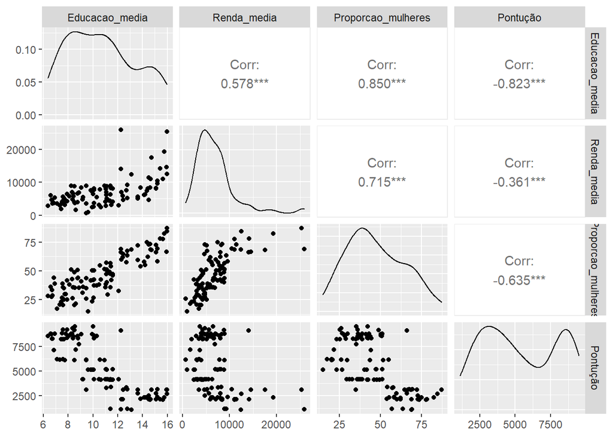

```r
dados=data.frame(Prestige$education, Prestige$income, Prestige$prestige,
                 Prestige$census)
colnames(dados)=c("Educacao_media","Renda_media", "Proporcao_mulheres","Pontução" )
ggpairs(dados)
```

```r
m=powerTransform(dados)
names(m)
```

```
##  [1] "value"       "counts"      "convergence" "message"     "hessian"
##  [6] "start"       "lambda"      "roundlam"    "invHess"     "llik"
## [11] "family"      "xqr"         "y"           "x"
```

```r
summary(m)
```

```
## bcPower Transformations to Multinormality
##                    Est Power Rounded Pwr Wald Lwr Bnd Wald Upr Bnd
## Educacao_media        0.8095        1.00       0.2831       1.3359
## Renda_media           0.2082        0.33       0.0354       0.3810
## Proporcao_mulheres    0.9549        1.00       0.6012       1.3085
## Pontução              0.6922        0.50       0.3877       0.9966
##
## Likelihood ratio test that transformation parameters are equal to 0
##  (all log transformations)
##                                  LRT df       pval
## LR test, lambda = (0 0 0 0) 56.34121  4 1.7006e-11
##
## Likelihood ratio test that no transformations are needed
##                                  LRT df       pval
## LR test, lambda = (1 1 1 1) 71.05226  4 1.3656e-14
```

```r
testTransform(m, c(1,0.3,1,.5))
```

```
##                                      LRT df    pval
## LR test, lambda = (1 0.3 1 0.5) 3.029857  4 0.55284
```

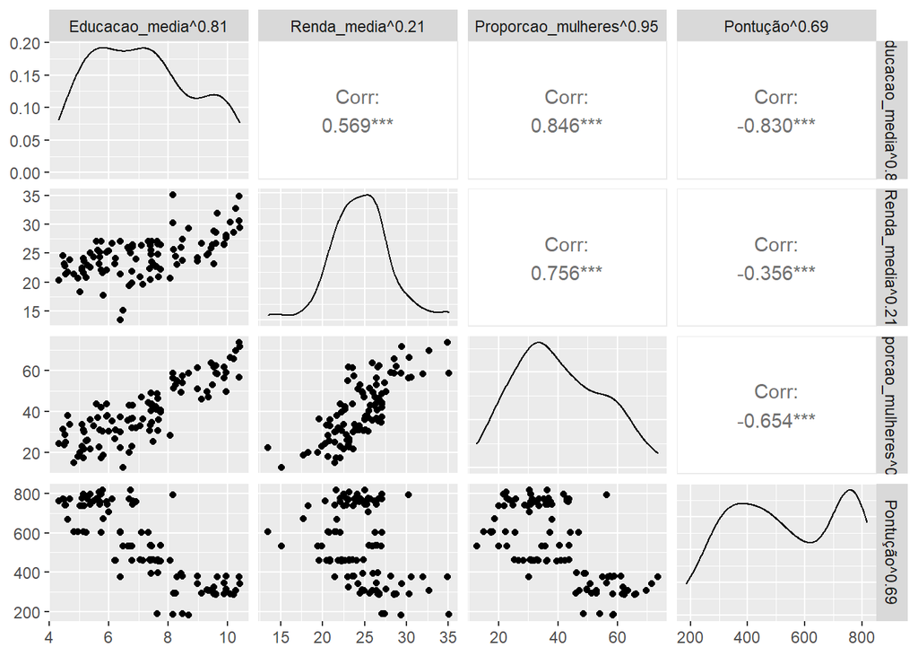

```r
d=bcPower(dados,m$lambda)
ggpairs(d)
```

```r
#####################################################
# Teste de normalidade
#####################################################
shapiro.test(d[,1])
```

```
##
##  Shapiro-Wilk normality test
##
## data:  d[, 1]
## W = 0.95381, p-value = 0.001308
```

```r
shapiro.test(d[,2])
```

```
##
##  Shapiro-Wilk normality test
##
## data:  d[, 2]
## W = 0.97699, p-value = 0.07193
```

```r
shapiro.test(d[,3])
```

```
##
##  Shapiro-Wilk normality test
##
## data:  d[, 3]
## W = 0.97373, p-value = 0.03952
```

```r
shapiro.test(d[,4])
```

```
##
##  Shapiro-Wilk normality test
##
## data:  d[, 4]
## W = 0.91214, p-value = 4.554e-06
```

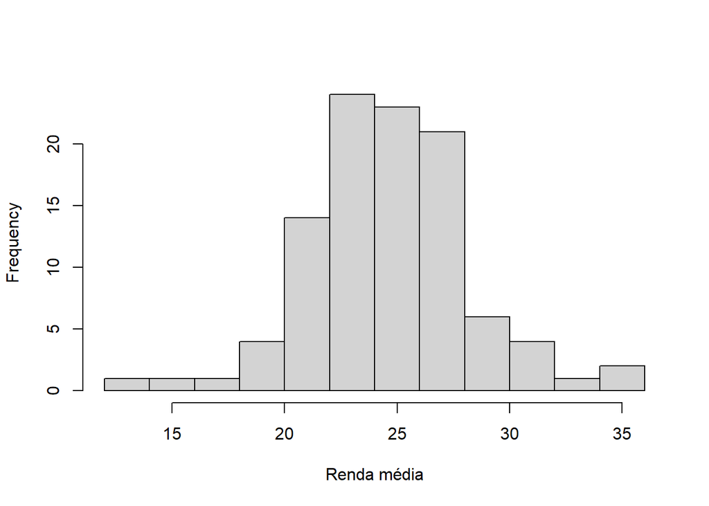

```r
hist(d[,2],main='',xlab='Renda média', nclass=10)
```

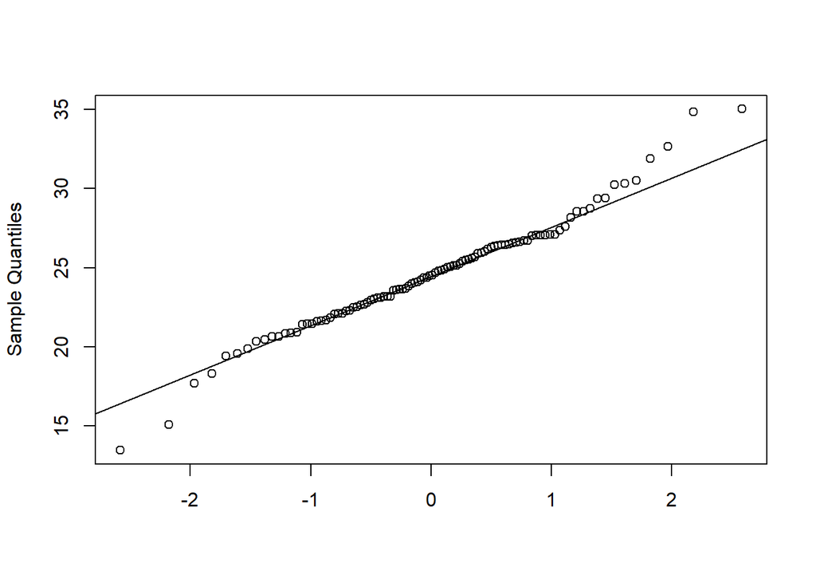

```r
    qqnorm(d[,2],main='',xlab='')
    qqline(d[,2])
```